# Harvard Machine Learning W1

Anna Takacs

12/27/2019

# Overall Accuracy

We have only one predictor and so, y is sex and x is height.

```r
data(heights)
y <- heights$sex
x <- heights$height
```

Randomly split the data into training and test sets.

- The argument `times` is used to define how many random samples of indexes to return.
- The agrument `p` is used to define what proportion of the index represented.
- Angument `list` is used to decide what indexes to be returned as a list of not.

```r
set.seed(2)
test_index <- createDataPartition(y, times = 1, p = 0.5, list = FALSE)
test_set <- heights[test_index, ]
train_set <- heights[-test_index, ]
```

### Overall accuracy:

*Evaluating algorithms when the outcome is categorical is simply by reproting the proportion of cases that were correcty predicted in the test set.*

To be able to demonstarte the use of overall accuracy, we build two competing algorithms and compare them:

**1) Guessing the outcome.**

Here, were ignoring the predictor and simply guessing the dependent variable.

```r
y_hat <- sample(c("Male", "Female"), length(test_index), replace = TRUE)
```

The `caret` package recommend categorical variables to be decoded as factors.

```r
y_hat <- sample(c("Male", "Female"), length(test_index), replace = TRUE)
y_hat <- y_hat %>%
  factor(levels = levels(test_set$sex))
```

Compute overall accuracy by showing the overall proportion that is predicted correctly:

```r
mean(y_hat == test_set$sex)
```

```
## [1] 0.4895238
```

BUT: we can do better because from the explanatory data analysis we can see that men are slighlty taller than females.

```r
heights %>% group_by(sex) %>% summarize(mean(height), sd(height))
```

```
## # A tibble: 2 x 3
##   sex    `mean(height)` `sd(height)`
##   <fct>           <dbl>        <dbl>
## 1 Female           64.9         3.76
## 2 Male             69.3         3.61
```

**2) Model 2**

In this model we try a simple approach: predict male if the height is within two standard devatition from the average male. The accuracy goes up to around 80% from the previous 50%.

```r
y_hat <- ifelse(x > 62, "Male", "Female") %>%
  factor(levels = levels(test_set$sex))
mean(y == y_hat)
```

```
## [1] 0.7933333
```

Here, we picked the cutoff at 62, but we can pick the best value on the training set. BUT: evaluating algorhithms on the training set can lead to overfitting - can lead to overly optimistic assessments.

Now, we examine the results with 10 different cutoffs.

```r
library(purrr)
```

```r
cutoff <- seq(61, 70)
accuracy <- map_dbl(cutoff, function(x){
        y_hat <- ifelse(train_set$height > x, "Male", "Female") %>%
                factor(levels = levels(test_set$sex))
        mean(y_hat == train_set$sex)
})
```

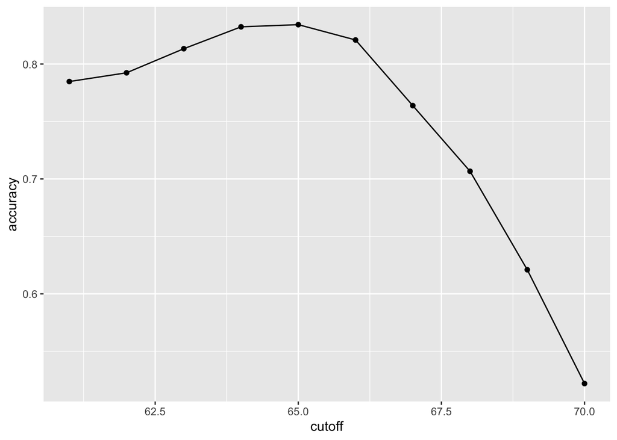

```r
data.frame(cutoff, accuracy) %>%
     ggplot(aes(cutoff, accuracy)) +
     geom_point() +
     geom_line()
```

The maximum value for accuracy is much higher than the previous 50%. See where we can achieve maximized accuracy:

```r
max(accuracy)
```

```
## [1] 0.8342857
```

```r
best_cutoff <- cutoff[which.max(accuracy)]
best_cutoff
```

```
## [1] 65
```

The accuracy is maximised at the 65 cutoff.

**Test the cutoff on the test set.**

```r
y_hat <- ifelse(test_set$height > best_cutoff, "Male", "Female") %>%
     factor(levels = levels(test_set$sex))
y_hat <- factor(y_hat)
mean(y_hat == test_set$sex)
```

```
## [1] 0.8190476
```

Here, the accuracy is around 81%. It is still better than guessing and we know that it’s not due to overfitting as we tested this on the testing dataset.

## Exercises

```r
#install.packages("dslabs")
library(dslabs)
mnist <- read_mnist()
```

[output not shown]

```r
mnist_x <- mnist$train$images
```

[output not shown]

```r
mnist_y <- mnist$train$labels
```

[output not shown]

```r
# Rename columns and standardize feature values
colnames(mnist_x) <- paste0("V", 1:ncol(mnist_x))
```

[output not shown]

```r
mnist_x <- mnist_x / 255
```

[output not shown]

```r
#One-hot encode response
mnist <- as.character(mnist_y, 10)
```

[output not shown]

```r
# Get number of features, which we'll use in our model.
p <- ncol(mnist_x)
```

[output not shown]

```r
p
```

[output not shown]

*Feature* is an individual measurable property or characteristic of a phenomenon being observed.

# Confusion Matrix

Overall accuracy can be a deciptive measure. -> To see this, we start constructing the confusion matrix - whihc tabulates each combination of prediction and actual value.

By using the table() function:

```r
table(predicted = y_hat, actual = test_set$sex)
```

```
##          actual
## predicted Female Male
##    Female     73   49
##    Male       46  357
```

```r
test_set %>%
     mutate(y_hat = y_hat) %>%
     group_by(sex) %>%
     summarize(accuracy = mean(y_hat == sex))
```

```
## # A tibble: 2 x 2
##   sex    accuracy
##   <fct>     <dbl>
## 1 Female    0.613
## 2 Male      0.879
```

We get a very high accuracy for males, but a lower accuracy for females. In other words, too many females are predicted to be males.

*How can the overall accuracy be so high then?* Because there are more males in the datatset than females.

```r
prev <- mean(y == "Male")
prev
```

```
## [1] 0.7733333
```

77% of the individuals in the dataset are males.

**If the training data is biased in some way, you are likely to develop an algorhithm that is biased as well.** -> Look at metrics other than overall accuracy when evaluating a machine learning algorhithm.

Metrics to evaluate an algorhithm where prevelance does not cloud our assessment: Can be derived from the confusion matrix: allow us to study sensitivity and specificity separately. In case of a categorical outcome, we can define sensitivity and specificity for a specific category.

*Sensitivity*: ability of an algorhithm to predict a positive outcome when the actual outcome is positive.

*Specificity*: the ability to NOT predict the positive when the actual value is not a positive.

High sensitivity: y = 1 implies y hat = 1

High specificity: y = 0 implies y hat = 0

**Confusion matrix:**

```r
mat <- matrix(c("True positives (TP)", "False negatives (FN)",
                "False positives (FP)", "True negatives (TN)"), 2, 2)
colnames(mat) <- c("Actually Positive", "Actually Negative")
rownames(mat) <- c("Predicted positve", "Predicted negative")
as.data.frame(mat) %>% knitr::kable()
```

|  | Actually Positive | Actually Negative |
| --- | --- | --- |
| Predicted positve | True positives (TP) | False positives (FP) |
| Predicted negative | False negatives (FN) | True negatives (TN) |

**Sensitivity:** True positive rate/ recall: TP/(TP+FN)

**Specificity:** True negative rate: TN/(TN+FP)

Positive predictive value/ precision: TP/(TP+FP) (It depends on the prevalance, since higher prevalence implies you can get higher precision even when guessing)

### Confusion matrix

We need to define what is positive. The function expects factors as inputs and the first level is considered the positive outcome y = 1.

In out example female is the first level as it comes before male alphabetically.

```r
confusionMatrix(data = y_hat, reference = test_set$sex)
```

```
## Confusion Matrix and Statistics
##
##           Reference
## Prediction Female Male
##     Female     73   49
##     Male       46  357
##
##                Accuracy : 0.819
##                  95% CI : (0.7834, 0.8511)
##     No Information Rate : 0.7733
##     P-Value [Acc > NIR] : 0.00616
##
##                   Kappa : 0.4884
##
##  Mcnemar's Test P-Value : 0.83742
##
##             Sensitivity : 0.6134
##             Specificity : 0.8793
##          Pos Pred Value : 0.5984
##          Neg Pred Value : 0.8859
##              Prevalence : 0.2267
##          Detection Rate : 0.1390
##    Detection Prevalence : 0.2324
##       Balanced Accuracy : 0.7464
##
##        'Positive' Class : Female
##
```

High overall accuracy is possible despite relatively low sensitivity. It happens because of the low prevalence.

-> Because prevalence is low, failing to call actual females females, LOW SENSITIVITY, does not lower the accuracy as much as it woulf have increased if incorrectly called males females.

# Balanced accuracy and F-score

Balanced accuracy: average of specificity and sensitivity (both of which are rates)

**F1 score**: harmonic average of precision and recall

*2 x (precision x recall)/(precision + recall)*

Depending on the context: some type of errors are more costly than others.

–> Plane safety: maximize sensitivity over specificity.

–> F1 can be adopted to weight specificity and sesitivity: we define `beta` tp represent how much more important sensitivity is compared ot specificity.

**Caret package**: F_meas() fucntion - computes the summary with beta defaulting to one

### Maximizing F score instead of overall accuracy

```r
cutoff <- seq(61, 70)
F_1 <- map_dbl(cutoff, function(x){
     y_hat <- ifelse(train_set$height > x, "Male", "Female") %>%
          factor(levels = levels(test_set$sex))
     F_meas(data = y_hat, reference = factor(train_set$sex))
})
```

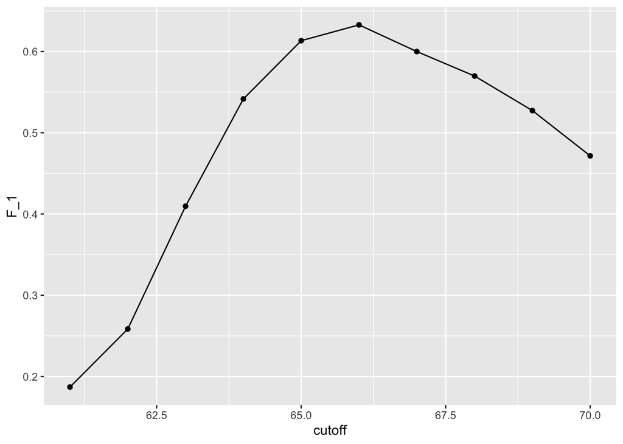

```r
data.frame(cutoff, F_1) %>%
     ggplot(aes(cutoff, F_1)) +
     geom_point() +
     geom_line()
```

```r
max(F_1)
```

```
## [1] 0.6328125
```

```r
best_cutoff <- cutoff[which.max(F_1)]
best_cutoff
```

```
## [1] 66
```

The cutoff of 66 makes much more sense.

And this result also balances the specificity and sentsitivity of our confusion matrix:

```r
y_hat <- ifelse(test_set$height > best_cutoff, "Male", "Female") %>%
     factor(levels = levels(test_set$sex))
confusionMatrix(data = y_hat, reference = test_set$sex)
```

```
## Confusion Matrix and Statistics
##
##           Reference
## Prediction Female Male
##     Female     82   77
##     Male       37  329
##
##                Accuracy : 0.7829
##                  95% CI : (0.7451, 0.8174)
##     No Information Rate : 0.7733
##     P-Value [Acc > NIR] : 0.3221872
##
##                   Kappa : 0.4464
##
##  Mcnemar's Test P-Value : 0.0002595
##
##             Sensitivity : 0.6891
##             Specificity : 0.8103
##          Pos Pred Value : 0.5157
##          Neg Pred Value : 0.8989
##              Prevalence : 0.2267
##          Detection Rate : 0.1562
##    Detection Prevalence : 0.3029
##       Balanced Accuracy : 0.7497
##
##        'Positive' Class : Female
##
```

We do much better than guessing and both sensitivity and specificity are relatively high.

This is our first machine learning algorithm: takes hight as a predictor and predicts female if you are 66 inches or shorter.

# Prevalence matters in practice

Machine learning algorhythm with high sensitivity and specificity: may not be useful in practice when prevalence is close to 1 or 0.

**Case**: Doctor who wants to predicts the rare disease, data has 50% of people who have the disease. Meaning that Y_hat equals 1/2.

But here, what is important is the precision of the test - the probability of y equals 1 given that Y_hat equals 1.

We can apply here Bayes’ theorem.

The doctor knwos that the prevalence of the disease is 5 in 1000. And the prevalence of the disease in the dataset is 50%.

And so:

Pr(y = 1) / Pr(Y_hat = 1) = 1/100

And so: the precision of the algorhythm is less than 0.01. The doctor cannot do much with the algothythm.

# ROC and precision-recall curves

Accuracy: only considered one cutoff - here we only considered with equal probability.

F1: one that used height and considered several cutoffs - clearly outperformed.

Here, guessing male with higher probability would give us higher accuracy due to bias in sample. This code prdicts male.

```r
p <- 0.9
y_hat <- sample(c("Male", "Female"), length(test_index), replace = TRUE, prob=c(p, 1-p)) %>%
     factor(levels = levels(test_set$sex))
mean(y_hat == test_set$sex)
```

```
## [1] 0.7180952
```

A very common approach to evaluating methods is to compare them graphically by plotting both: the receiver operating characteristic or ROC.

ROC + true positive rate **OR** 1-false positive rate.

ROC curve for guessing sex but using different probabilities of guessing male:

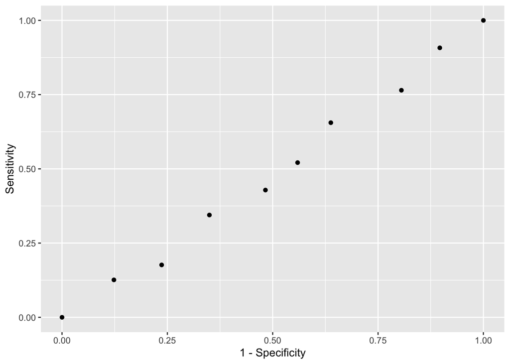

```r
probs <- seq(0, 1, length.out = 10)
guessing <- map_df(probs, function(p){
     y_hat <-
          sample(c("Male", "Female"), length(test_index), replace = TRUE, prob=c(p, 1-p)) %>%
          factor(levels = c("Female", "Male"))
     list(method = "Guessing",
          FPR = 1 - specificity(y_hat, test_set$sex),
          TPR = sensitivity(y_hat, test_set$sex))
})
guessing %>% qplot(FPR, TPR, data =., xlab = "1 - Specificity", ylab = "Sensitivity")
```

The perfect algorhythm would shoot straight to one and stay up there, meaning perfect sensitivity for all values of specificity.

Construct an ROC curve for a height-based approach:

```r
cutoffs <- c(50, seq(60, 75), 80)
height_cutoff <- map_df(cutoffs, function(x){
     y_hat <- ifelse(test_set$height > x, "Male", "Female") %>%
          factor(levels = c("Female", "Male"))
     list(method = "Height cutoff",
          FPR = 1-specificity(y_hat, test_set$sex),
          TPR = sensitivity(y_hat, test_set$sex))
})
```

Plotting both curves together, we are able to compare sensitivity for different values of specificity:

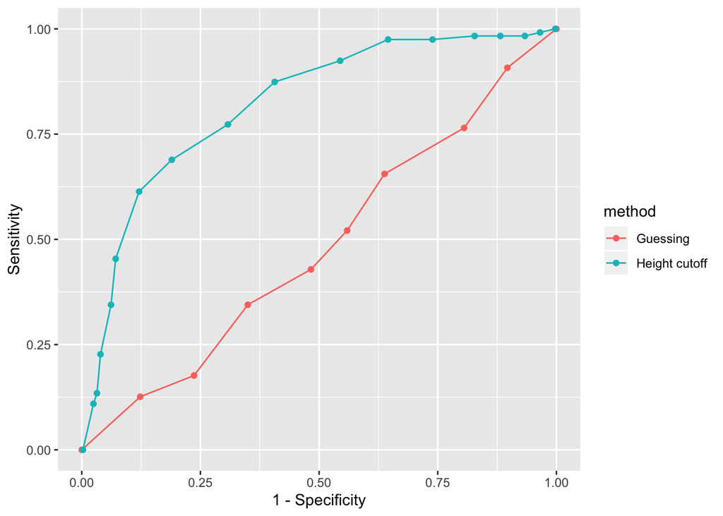

```r
bind_rows(guessing, height_cutoff) %>%
     ggplot(aes(FPR, TPR, color = method)) +
     geom_line() +
     geom_point() +
     xlab("1 - Specificity") +
     ylab("Sensitivity")
```

We obtain higher sensitivity with the height-based approach for all values of specificiity- which implies that it is a better method.

Adding cutoff to the points:

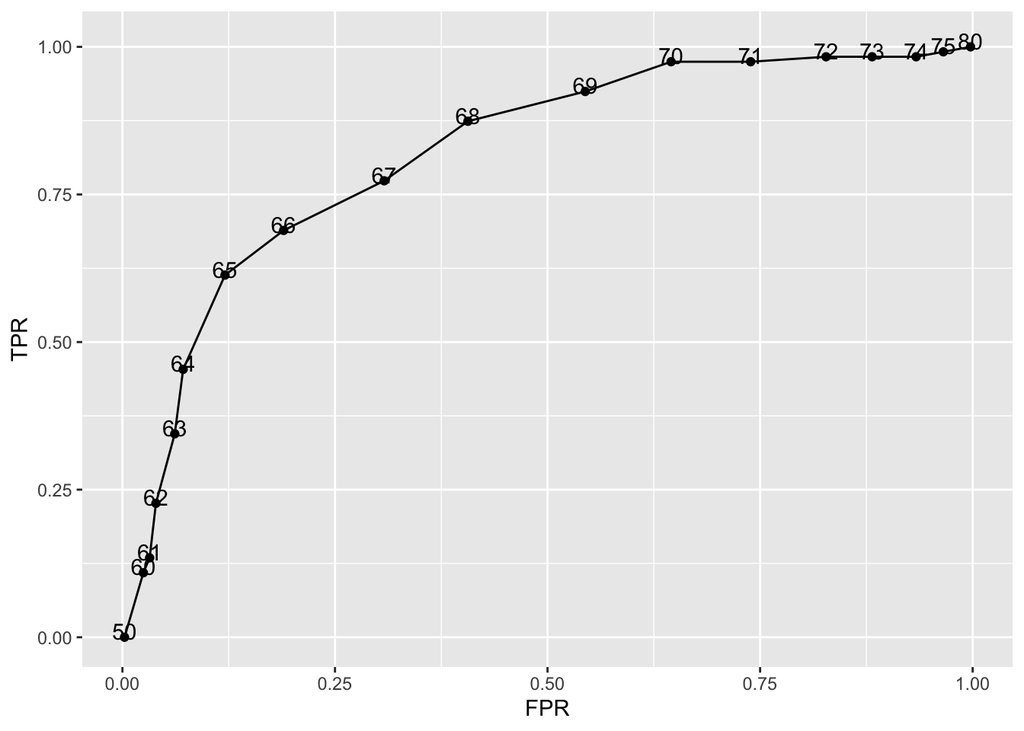

```r
map_df(cutoffs, function(x){
     y_hat <- ifelse(test_set$height > x, "Male", "Female") %>%
          factor(levels = c("Female", "Male"))
     list(method = "Height cutoff",
          cutoff = x,
          FPR = 1-specificity(y_hat, test_set$sex),
          TPR = sensitivity(y_hat, test_set$sex))
}) %>%
     ggplot(aes(FPR, TPR, label = cutoff)) +
     geom_line() +
     geom_point() +
     geom_text(nudge_y = 0.01)
```

ROC has one weakness: neither of the measures depend on prevalence.

In cases where pevalence matters we may make a precision-recall plot. - Plots precision over recall.

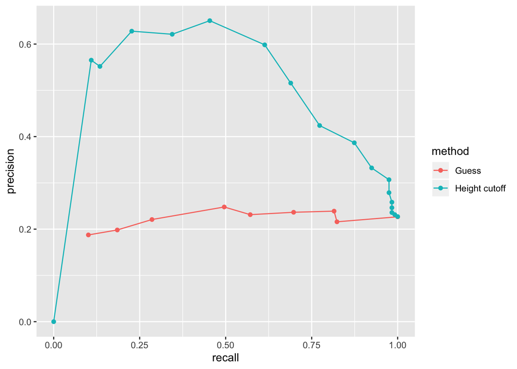

```r
guessing <- map_df(probs, function(p){
     y_hat <- sample(c("Male", "Female"), length(test_index),
                     replace = TRUE, prob=c(p, 1-p)) %>%
          factor(levels = c("Female", "Male"))
     list(method = "Guess",
          recall = sensitivity(y_hat, test_set$sex),
          precision = precision(y_hat, test_set$sex))
})
height_cutoff <- map_df(cutoffs, function(x){
     y_hat <- ifelse(test_set$height > x, "Male", "Female") %>%
          factor(levels = c("Female", "Male"))
     list(method = "Height cutoff",
          recall = sensitivity(y_hat, test_set$sex),
          precision = precision(y_hat, test_set$sex))
})
bind_rows(guessing, height_cutoff) %>%
     ggplot(aes(recall, precision, color = method)) +
     geom_line() +
     geom_point()
```

Precision of guessing is not high. This is because the prevalence is low.

If we change positives to mean male instead of females, the ROC curve remains the same - but the precision-recall plot changes.

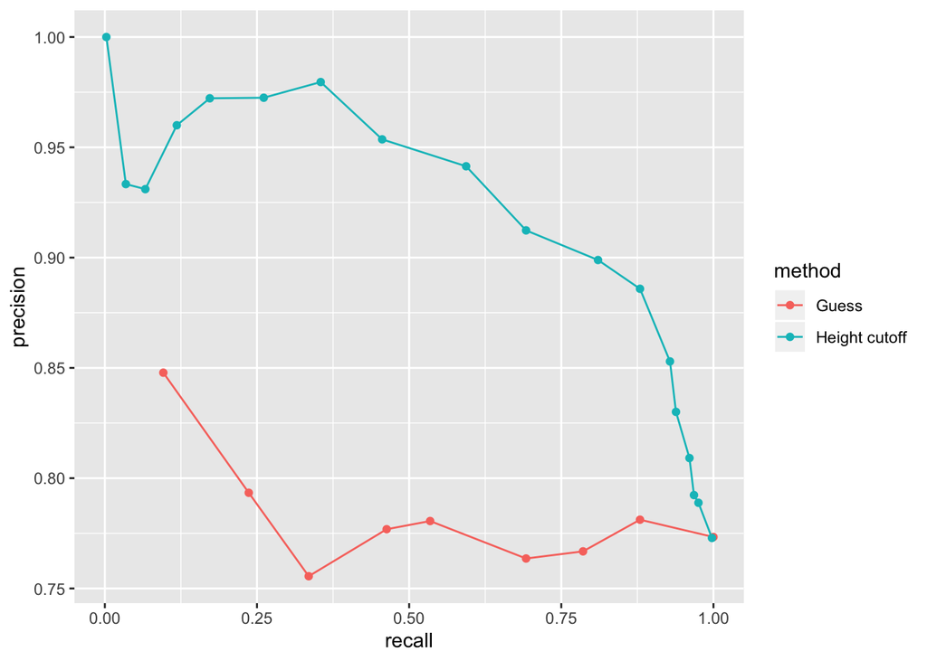

```r
guessing <- map_df(probs, function(p){
     y_hat <- sample(c("Male", "Female"), length(test_index), replace = TRUE,
                     prob=c(p, 1-p)) %>%
          factor(levels = c("Male", "Female"))
     list(method = "Guess",
          recall = sensitivity(y_hat, relevel(test_set$sex, "Male", "Female")),
          precision = precision(y_hat, relevel(test_set$sex, "Male", "Female")))
})
height_cutoff <- map_df(cutoffs, function(x){
     y_hat <- ifelse(test_set$height > x, "Male", "Female") %>%
          factor(levels = c("Male", "Female"))
     list(method = "Height cutoff",
          recall = sensitivity(y_hat, relevel(test_set$sex, "Male", "Female")),
          precision = precision(y_hat, relevel(test_set$sex, "Male", "Female")))
})
bind_rows(guessing, height_cutoff) %>%
     ggplot(aes(recall, precision, color = method)) +
     geom_line() +
     geom_point()
```

## Exercises

**Question 1**

```r
library(dslabs)
library(dplyr)
library(lubridate)
data("reported_heights")
```

```r
dat <- mutate(reported_heights, date_time = ymd_hms(time_stamp)) %>%
  filter(date_time >= make_date(2016, 01, 25) & date_time < make_date(2016, 02, 1)) %>%
  mutate(type = ifelse(day(date_time) == 25 & hour(date_time) == 8 & between(minute(date_time), 15, 30), "inclass","online")) %>%
  select(sex, type)

y <- factor(dat$sex, c("Female", "Male"))
x <- dat$type
```

```r
library(dplyr)
dat_inclass <- dat %>%
  filter(dat$type == "inclass")
table <- table(dat_inclass$sex)
round(prop.table(table), 2)
```

```
##
## Female   Male
##   0.67   0.33
```

```r
dat_online <- dat %>%
  filter(dat$type == "online")
table1 <- table(dat_online$sex)
round(prop.table(table1), 2)
```

```
##
## Female   Male
##   0.38   0.62
```

**Question 2**

```r
y_hat <- ifelse(x == "online", "Male", "Female") %>%
  factor(levels = levels(y))
mean(y == y_hat)
```

```
## [1] 0.6333333
```

**Question 3**_

```r
table(y_hat, y)
```

```
##         y
## y_hat    Female Male
##   Female     26   13
##   Male       42   69
```

**Question 4**

```r
sensitivity(y_hat, y)
```

```
## [1] 0.3823529
```

```r
specificity(y_hat, y)
```

```
## [1] 0.8414634
```

**Question 5**

```r
sex <- table(dat$sex)
prop.table(sex)
```

```
##
##    Female      Male
## 0.4533333 0.5466667
```

**Question 7**

```r
library(caret)
data(iris)
iris <- iris[-which(iris$Species=='setosa'),]
y <- iris$Species
```

```r
set.seed(2, sample.kind = "Rounding")
test_index <- createDataPartition(y, times = 1,p = 0.5, list = FALSE)
test <- iris[test_index,]
train <- iris[-test_index,]
```

**Question 8**

Sepal.Length

Sepal.Width

Petal.Length

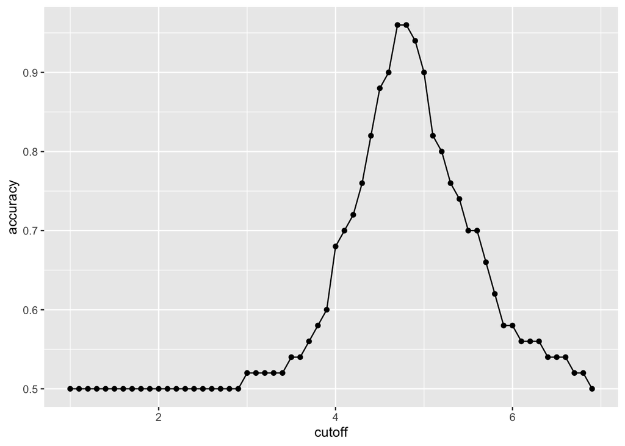

```r
y_hat <- sample(c("virginica", "versicolor"), length(test_index), replace = TRUE)

cutoff <- seq(1.0, 6.9, 0.1)
accuracy <- map_dbl(cutoff, function(x){
  y_hat <- ifelse(train$Petal.Length > x, "virginica", "versicolor") %>%
          factor(levels = levels(train$Species))
        mean(y_hat == train$Species)
})

data.frame(cutoff, accuracy) %>%
     ggplot(aes(cutoff, accuracy)) +
     geom_point() +
     geom_line()
```

```r
max(accuracy)
```

```
## [1] 0.96
```

Petal.Width

The highest accuracy is for the Petal.Length variable.

**Question 9** Calculate overall accuracy in the test data.

```r
best_cutoff <- cutoff[which.max(accuracy)]
best_cutoff
```

```
## [1] 4.7
```

```r
y_hat <- ifelse(test$Petal.Length > best_cutoff, "virginica", "versicolor") %>%
          factor(levels = levels(test$Species))
        mean(y_hat == test$Species)
```

```
## [1] 0.9
```

**Question 10**

```r
# Sepal.Length
y_hat <- sample(c("virginica", "versicolor"), length(test_index), replace = TRUE)

library(purrr)
cutoff <- seq(4.9, 7.9, 0.1)
accuracy <- map_dbl(cutoff, function(x){
        y_hat <- ifelse(train$Sepal.Length > x, "virginica", "versicolor") %>%
          factor(levels = levels(train$Species))
        mean(y_hat == train$Species)
})
max(accuracy)
```

```
## [1] 0.7
```

```r
# Max overall accuracy
best_cutoff <- cutoff[which.max(accuracy)]
best_cutoff
```

```
## [1] 6.2
```

```r
y_hat <- ifelse(test$Sepal.Length > best_cutoff, "virginica", "versicolor") %>%
          factor(levels = levels(test$Species))
        mean(y_hat == test$Species)
```

```
## [1] 0.76
```

```r
# Sepal Width
y_hat <- sample(c("virginica", "versicolor"), length(test_index), replace = TRUE)

cutoff <- seq(2.0, 3.8, 0.1)
accuracy <- map_dbl(cutoff, function(x){
        y_hat <- ifelse(train$Sepal.Width > x, "virginica", "versicolor") %>%
          factor(levels = levels(train$Species))
        mean(y_hat == train$Species)
})

max(accuracy)
```

```
## [1] 0.62
```

```r
# Max overall accuracy
best_cutoff <- cutoff[which.max(accuracy)]
best_cutoff
```

```
## [1] 2.4
```

```r
y_hat <- ifelse(test$Sepal.Width > best_cutoff, "virginica", "versicolor") %>%
          factor(levels = levels(test$Species))
        mean(y_hat == test$Species)
```

```
## [1] 0.54
```

```r
# Petal Width
y_hat <- sample(c("virginica", "versicolor"), length(test_index), replace = TRUE)

cutoff <- seq(1.0, 2.5, 0.1)
accuracy <- map_dbl(cutoff, function(x){
  y_hat <- ifelse(train$Petal.Width > x, "virginica", "versicolor") %>%
          factor(levels = levels(train$Species))
        mean(y_hat == train$Species)
})

max(accuracy)
```

```
## [1] 0.94
```

```r
# Max overall accuracy
best_cutoff <- cutoff[which.max(accuracy)]
best_cutoff
```

```
## [1] 1.5
```

```r
y_hat <- ifelse(test$Petal.Width > best_cutoff, "virginica", "versicolor") %>%
          factor(levels = levels(test$Species))
        mean(y_hat == test$Species)
```

```
## [1] 0.9
```

**Question 11**

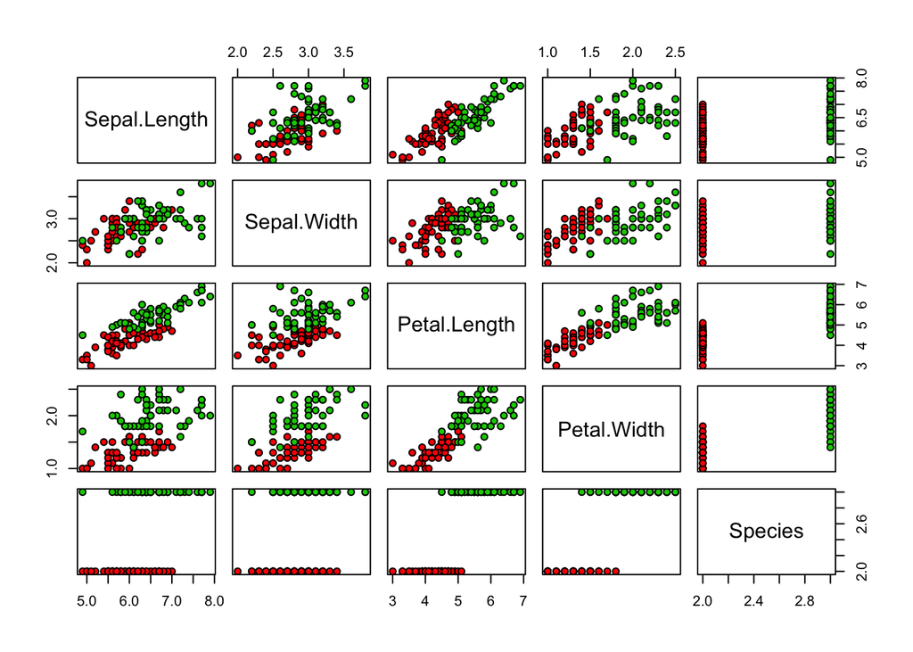

```r
plot(iris, pch = 21,bg = iris$Species)
```

Optimize cutoff separately in the training dataset for Petal.Length and Petal.Width Petal.Length

```r
y_hat <- sample(c("virginica", "versicolor"), length(test_index), replace = TRUE)

cutoff <- seq(1.0, 6.9, 0.1)
accuracy <- map_dbl(cutoff, function(x){
  y_hat <- ifelse(train$Petal.Length > x, "virginica", "versicolor") %>%
          factor(levels = levels(train$Species))
        mean(y_hat == train$Species)
})
max(accuracy)
```

```
## [1] 0.96
```

```r
best_cutoff_length <- cutoff[which.max(accuracy)]
best_cutoff_length
```

```
## [1] 4.7
```

The best cutoff for the Petal.Length variable is 4.7.

Petal.Width

```r
y_hat <- sample(c("virginica", "versicolor"), length(test_index), replace = TRUE)

cutoff <- seq(1.0, 2.5, 0.1)
accuracy <- map_dbl(cutoff, function(x){
  y_hat <- ifelse(train$Petal.Width > x, "virginica", "versicolor") %>%
          factor(levels = levels(train$Species))
        mean(y_hat == train$Species)
})

max(accuracy)
```

```
## [1] 0.94
```

```r
# Max overall accuracy
best_cutoff_width <- cutoff[which.max(accuracy)]
best_cutoff_width
```

```
## [1] 1.5
```

The best cutoff for the Petal.Width variable is 1.5.

```r
y_hat <- ifelse((test$Petal.Length > best_cutoff_length) | (test$Petal.Width > best_cutoff_length), "virginica", "versicolor") %>%
          factor(levels = levels(test$Species))
        mean(y_hat == test$Species)
```

```
## [1] 0.9
```